# Practical Machine Learning Course Project

Jack Chen

December 10, 2016

## Overview

Using devices such as Jawbone Up, Nike FuelBand, and Fitbit it is now possible to collect a large amount of data about personal activity relatively inexpensively. A group of enthusiasts who take measurements about themselves regularly are trying to improve their health, to find patterns in their behavior, or because they are tech geeks.

One thing that people regularly do is quantify *how much* of a particular activity they do, but they rarely quantify *how well* they do it. In this project, the goal is to use data from accelerometers on the belt, forearm, arm, and dumbell of 6 participants, who were asked to perform barbell lifts correctly and incorrectly in 5 different ways, to predict the manner in which they did the exercise.

This is the “classe” variable in the training set. By using any of the other variables to predict with, I will create a report describing how I build the model, how I use cross validation, what I think the expected out of sample error is, and why I make the choices.

## Load Relevant Libraries

```r
library(caret)
library(lars)
library(elasticnet)
library(rpart)
library(rattle)
```

```r
library(rpart.plot)
library(plyr)
```

## Load Data

```r
#Create Training and Test Sets
trainUrl <- "https://d396qusza40orc.cloudfront.net/predmachlearn/pml-training.csv"
testUrl <- "https://d396qusza40orc.cloudfront.net/predmachlearn/pml-testing.csv"

training = read.csv(trainUrl, stringsAsFactors = FALSE, na.strings=c("","NA","#DIV/01"))
testing = read.csv(testUrl,stringsAsFactors = FALSE, na.strings=c("","NA","#DIV/01"))

dim(training)
```

```
## [1] 19622   160
```

```r
#names(training)

#testing doesn't have lots of data
dim(testing)
```

```
## [1]  20 160
```

```r
#partitioning trainging datA
inTrain <- createDataPartition(training$classe, p=0.6, list=FALSE)

partTraining <- training[inTrain,]
partTesting <- training[-inTrain,]

dim(partTraining)
```

```
## [1] 11776   160
```

```r
dim(partTesting)
```

```
## [1] 7846  160
```

```r
#tidy data
#remove Near Zero Covariates
nzvTraining<-nearZeroVar(partTraining,saveMetrics=TRUE)
partTraining<-partTraining[,!nzvTraining[4]]
partTesting<-partTesting[,!nzvTraining[4]]

dim(partTraining)
```

```
## [1] 11776   121
```

```r
dim(partTesting)
```

```
## [1] 7846  121
```

```r
#remove sequence number in the first column
partTraining<-partTraining[c(-1)]
partTesting<-partTesting[c(-1)]

dim(partTraining)
```

```
## [1] 11776   120
```

```r
dim(partTesting)
```

```
## [1] 7846  120
```

```r
#Clean variables with more than 60% NA
newTrain<-partTraining
for(i in 1:length(partTraining)){
  if(sum(is.na(partTraining[,i]))/nrow(partTraining)>=.7){
    for(j in 1:length(newTrain)){
      if(length(grep(names(partTraining)[i],names(newTrain)[j]))==1){
        newTrain<-newTrain[,-j]
      }
    }
  }
}
partTraining<-newTrain
rm(newTrain)
dim(partTraining)
```

```
## [1] 11776    58
```

```r
names(partTraining)
```

```
##  [1] "user_name"            "raw_timestamp_part_1" "raw_timestamp_part_2"
##  [4] "cvtd_timestamp"       "num_window"           "roll_belt"
##  [7] "pitch_belt"           "yaw_belt"             "total_accel_belt"
## [10] "gyros_belt_x"         "gyros_belt_y"         "gyros_belt_z"
## [13] "accel_belt_x"         "accel_belt_y"         "accel_belt_z"
## [16] "magnet_belt_x"        "magnet_belt_y"        "magnet_belt_z"
## [19] "roll_arm"             "pitch_arm"            "yaw_arm"
## [22] "total_accel_arm"      "gyros_arm_x"          "gyros_arm_y"
## [25] "gyros_arm_z"          "accel_arm_x"          "accel_arm_y"
## [28] "accel_arm_z"          "magnet_arm_x"         "magnet_arm_y"
## [31] "magnet_arm_z"         "roll_dumbbell"        "pitch_dumbbell"
## [34] "yaw_dumbbell"         "total_accel_dumbbell" "gyros_dumbbell_x"
## [37] "gyros_dumbbell_y"     "gyros_dumbbell_z"     "accel_dumbbell_x"
## [40] "accel_dumbbell_y"     "accel_dumbbell_z"     "magnet_dumbbell_x"
## [43] "magnet_dumbbell_y"    "magnet_dumbbell_z"    "roll_forearm"
## [46] "pitch_forearm"        "yaw_forearm"          "total_accel_forearm"
## [49] "gyros_forearm_x"      "gyros_forearm_y"      "gyros_forearm_z"
## [52] "accel_forearm_x"      "accel_forearm_y"      "accel_forearm_z"
## [55] "magnet_forearm_x"     "magnet_forearm_y"     "magnet_forearm_z"
## [58] "classe"
```

```r
#Synch columns in testing data
synchCol<-colnames(partTraining)
synchCol1<-colnames(partTraining[,-58]) #without classe column

partTesting<-partTesting[synchCol] #synch columns in partTesting with partTraining
testing<-testing[synchCol1] #synch columns in testing with partTraining

dim(partTesting)
```

```
## [1] 7846   58
```

```r
dim(testing)
```

```
## [1] 20 57
```

```r
#Synch data type for testing
backTesting<-testing
for(i in 1:length(testing)){
  for(j in 1:length(partTraining)){
   if(length(grep(names(partTraining)[j],names(testing)[i]))==1){
     class(testing[i])<-class(partTraining[j])
   }
  }
}

#synch class
testing<-rbind(partTraining[2,-58],testing)
testing<-testing[-1,]
testing$classe<-""
dim(testing)
```

```
## [1] 20 58
```

## Prediction with Decision Tree

```r
set.seed(233)
modFitDT<-train(classe ~ ., data=partTraining, method="rpart")
modFitDT$finalModel
```

```
## n= 11776
##
## node), split, n, loss, yval, (yprob)
##       * denotes terminal node
##
##  1) root 11776 8428 A (0.28 0.19 0.17 0.16 0.18)
##    2) roll_belt< 130.5 10772 7431 A (0.31 0.21 0.19 0.18 0.11)
##      4) pitch_forearm< -34 941    4 A (1 0.0043 0 0 0) *
##      5) pitch_forearm>=-34 9831 7427 A (0.24 0.23 0.21 0.2 0.12)
##       10) cvtd_timestamp02/12/2011 13:33>=0.5 796  202 A (0.75 0.25 0 0 0) *
##       11) cvtd_timestamp02/12/2011 13:33< 0.5 9035 6962 B (0.2 0.23 0.23 0.21 0.13)
##         22) magnet_dumbbell_z< -17.5 3541 2267 A (0.36 0.28 0.1 0.21 0.05) *
##         23) magnet_dumbbell_z>=-17.5 5494 3808 C (0.098 0.2 0.31 0.22 0.18) *
##    3) roll_belt>=130.5 1004    7 E (0.007 0 0 0 0.99) *
```

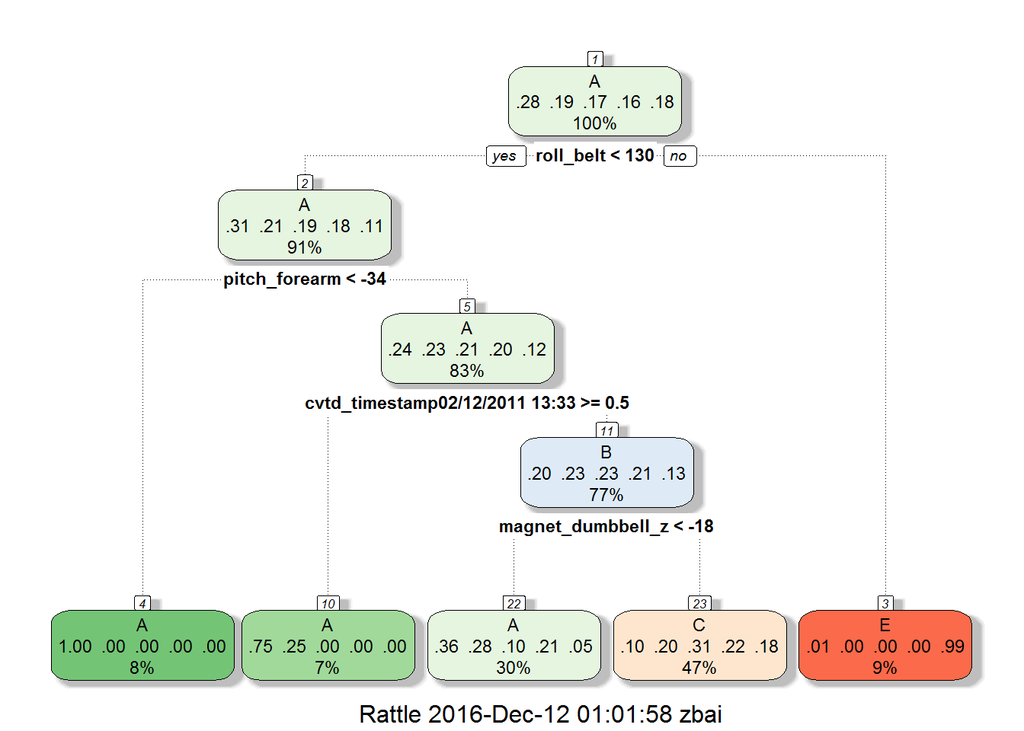

```r
fancyRpartPlot(modFitDT$finalModel)
```

```r
predictDT<-predict(modFitDT,partTesting)
cmTree<-confusionMatrix(predictDT, partTesting$classe)
cmTree
```

```
## Confusion Matrix and Statistics
##
##           Reference
## Prediction    A    B    C    D    E
##          A 1882  807  253  487  135
##          B    0    0    0    0    0
##          C  343  711 1115  799  673
##          D    0    0    0    0    0
##          E    7    0    0    0  634
##
## Overall Statistics
##
##                Accuracy : 0.4628
##                  95% CI : (0.4517, 0.4739)
##     No Information Rate : 0.2845
##     P-Value [Acc > NIR] : < 2.2e-16
##
##                   Kappa : 0.3067
##  Mcnemar's Test P-Value : NA
##
## Statistics by Class:
##
##                      Class: A Class: B Class: C Class: D Class: E
## Sensitivity            0.8432   0.0000   0.8151   0.0000  0.43967
## Specificity            0.7004   1.0000   0.6101   1.0000  0.99891
## Pos Pred Value         0.5281      NaN   0.3062      NaN  0.98908
## Neg Pred Value         0.9183   0.8065   0.9398   0.8361  0.88786
## Prevalence             0.2845   0.1935   0.1744   0.1639  0.18379
## Detection Rate         0.2399   0.0000   0.1421   0.0000  0.08081
## Detection Prevalence   0.4542   0.0000   0.4641   0.0000  0.08170
## Balanced Accuracy      0.7718   0.5000   0.7126   0.5000  0.71929
```

```r
#plot(cmTree$table,col=cmTree$byClass, main=paste("Decision Tree Confusion Matrix: Accuracy = ",round(cmTree$overall["Accuracy"],4)))
```

## Prediction with Generalized Boosted Regression

```r
set.seed(1234)
fitControl<-trainControl(method="repeatedcv", number=5, repeats=1)
modFitgbm<-train(classe~.,method="gbm", data=partTraining, trControl=fitControl, verbose=FALSE)
modFitgbm
```

```
## Stochastic Gradient Boosting
##
## 11776 samples
##    57 predictor
##     5 classes: 'A', 'B', 'C', 'D', 'E'
##
## No pre-processing
## Resampling: Cross-Validated (5 fold, repeated 1 times)
## Summary of sample sizes: 9420, 9420, 9420, 9422, 9422
## Resampling results across tuning parameters:
##
##   interaction.depth  n.trees  Accuracy   Kappa
##   1                   50      0.8401837  0.7971552
##   1                  100      0.9022577  0.8762306
##   1                  150      0.9272242  0.9078117
##   2                   50      0.9558427  0.9440845
##   2                  100      0.9848842  0.9808780
##   2                  150      0.9917627  0.9895800
##   3                   50      0.9831853  0.9787277
##   3                  100      0.9926963  0.9907614
##   3                  150      0.9966877  0.9958104
##
## Tuning parameter 'shrinkage' was held constant at a value of 0.1
##
## Tuning parameter 'n.minobsinnode' was held constant at a value of 10
## Accuracy was used to select the optimal model using  the largest value.
## The final values used for the model were n.trees = 150,
##  interaction.depth = 3, shrinkage = 0.1 and n.minobsinnode = 10.
```

```r
preditgbm<-predict(modFitgbm,partTesting)
cmgbm<-confusionMatrix(preditgbm,partTesting$classe)
cmgbm
```

```
## Confusion Matrix and Statistics
##
##           Reference
## Prediction    A    B    C    D    E
##          A 2232    3    0    0    0
##          B    0 1512    3    0    0
##          C    0    2 1354    3    0
##          D    0    1   11 1281    3
##          E    0    0    0    2 1439
##
## Overall Statistics
##
##                Accuracy : 0.9964
##                  95% CI : (0.9948, 0.9976)
##     No Information Rate : 0.2845
##     P-Value [Acc > NIR] : < 2.2e-16
##
##                   Kappa : 0.9955
##  Mcnemar's Test P-Value : NA
##
## Statistics by Class:
##
##                      Class: A Class: B Class: C Class: D Class: E
## Sensitivity            1.0000   0.9960   0.9898   0.9961   0.9979
## Specificity            0.9995   0.9995   0.9992   0.9977   0.9997
## Pos Pred Value         0.9987   0.9980   0.9963   0.9884   0.9986
## Neg Pred Value         1.0000   0.9991   0.9978   0.9992   0.9995
## Prevalence             0.2845   0.1935   0.1744   0.1639   0.1838
## Detection Rate         0.2845   0.1927   0.1726   0.1633   0.1834
## Detection Prevalence   0.2849   0.1931   0.1732   0.1652   0.1837
## Balanced Accuracy      0.9997   0.9978   0.9945   0.9969   0.9988
```

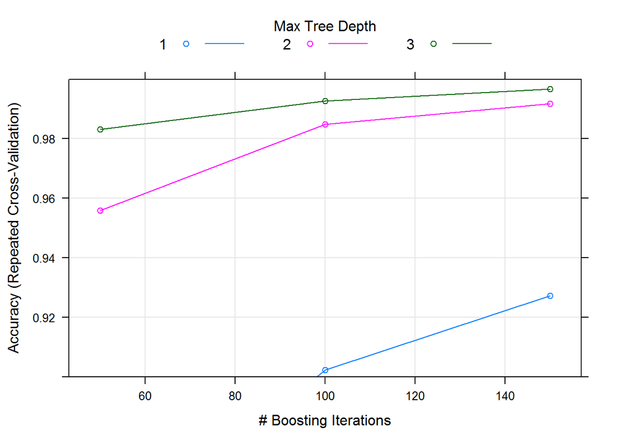

```r
plot(modFitgbm, ylim=c(0.9,1))
```

## Predicting Results on the Test Data

GBM gave an Accurary in the partTesting dataset of 99.64%, which was more accurate than Decision Tree. The expected out-of-sample error is 100-99.64 = 0.36%

```r
predictgbm1<-predict(modFitgbm, testing)
predictgbm1
```

```
##  [1] B A B A A E D B A A B C B A E E A B B B
## Levels: A B C D E
```